# Homework 3

# Q2

Continuing with the penguins dataset, let’s practice making some plots. For each variable in the dataset, choose one of the following plots to make that is appropriate for that data type. You must use each plot type at least once! Also make sure to properly annotate all plots!

- Histogram
- Density plot
- Box plot
- Bar plot
- One more plot type of your choice (you can read ahead in the notes to pick one, or perhaps find one from the ggplot [website](https://ggplot2.tidyverse.org) or [cheatsheet](https://rstudio.github.io/cheatsheets/data-visualization.pdf))

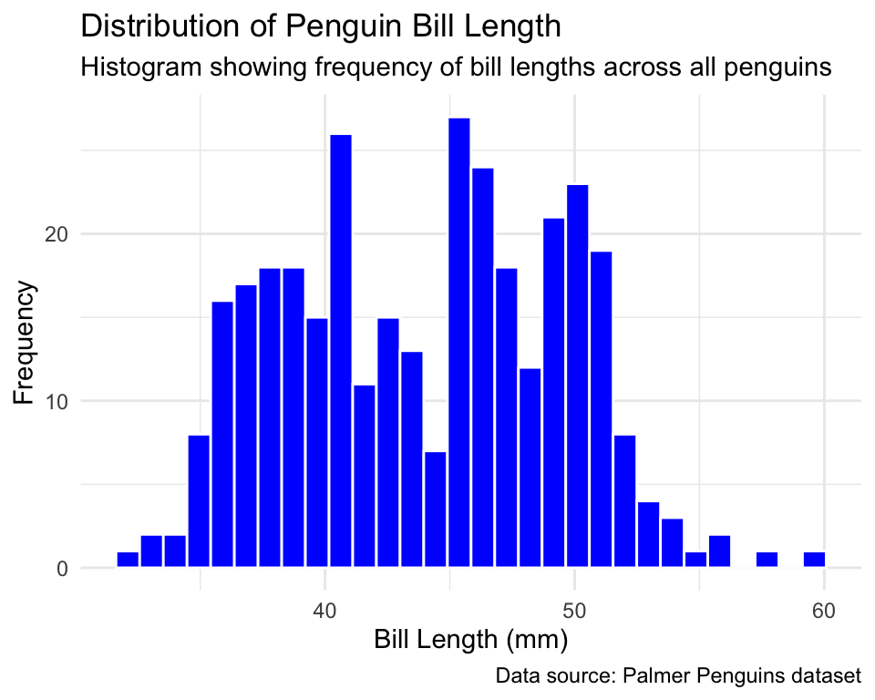

```r
#histogram for bill length :


plot1 <- ggplot(penguins, aes(x = bill_length_mm)) +
  geom_histogram(fill = "blue", color = "white") +
  labs(title = "Distribution of Penguin Bill Length",
       subtitle = "Histogram showing frequency of bill lengths across all penguins",
       x = "Bill Length (mm)",
       y = "Frequency",
       caption = "Data source: Palmer Penguins dataset") +
  theme_minimal()


# 2. DENSITY PLOT - Body Mass
plot2 <- ggplot(penguins, aes(x = body_mass_g)) +
  geom_density(fill = "lightblue", color = "red") +
  labs(title = "Density Distribution of Penguin Body Mass",
       subtitle = "Smooth density curve showing the distribution shape",
       x = "Body Mass (g)",
       y = "Density",
       caption = "Data source: Palmer Penguins dataset") +
  theme_minimal()

# 3. BOX PLOT - Flipper Length by Species
plot3 <- ggplot(penguins, aes(x = species, y = flipper_length_mm, fill = species)) +
  geom_boxplot() +
  labs(title = "Flipper Length Distribution by Penguin Species",
       subtitle = "Box plots showing median, quartiles, and outliers for each species",
       x = "Species",
       y = "Flipper Length (mm)",
       fill = "Species",
       caption = "Data source: Palmer Penguins dataset") +
  theme_minimal()

# 4. BAR PLOT - Count of Penguins by Island
plot4 <- ggplot(penguins, aes(x = island, fill = island)) +
  geom_bar() +
  labs(title = "Number of Penguins by Island",
       subtitle = "Bar chart showing penguin counts across different islands",
       x = "Island",
       y = "Count of Penguins",
       fill = "Island",
       caption = "Data source: Palmer Penguins dataset") +
  theme_minimal()

# 5. VIOLIN PLOT - Bill Depth by Sex

plot5 <- ggplot(penguins, aes(x = sex, y = bill_depth_mm, fill = sex)) +

  geom_violin(alpha = 0.7) +
  geom_boxplot(width = 0.1, fill = "white", alpha = 0.8) +
  labs(title = "Bill Depth Distribution by Sex",
       subtitle = "Violin plots with embedded box plots showing distribution shape and summary statistics",
       x = "Sex",
       y = "Bill Depth (mm)",
       fill = "Sex",
       caption = "Data source: Palmer Penguins dataset") +
  theme_minimal() +
  scale_fill_manual(values = c("female" = "purple", "male" = "black"))






# Display all plots
plot1
```

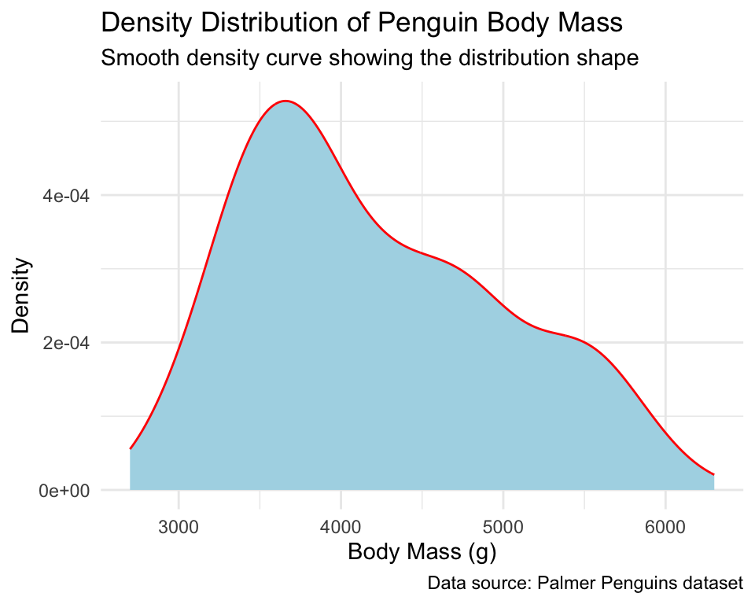

```r
plot2
```

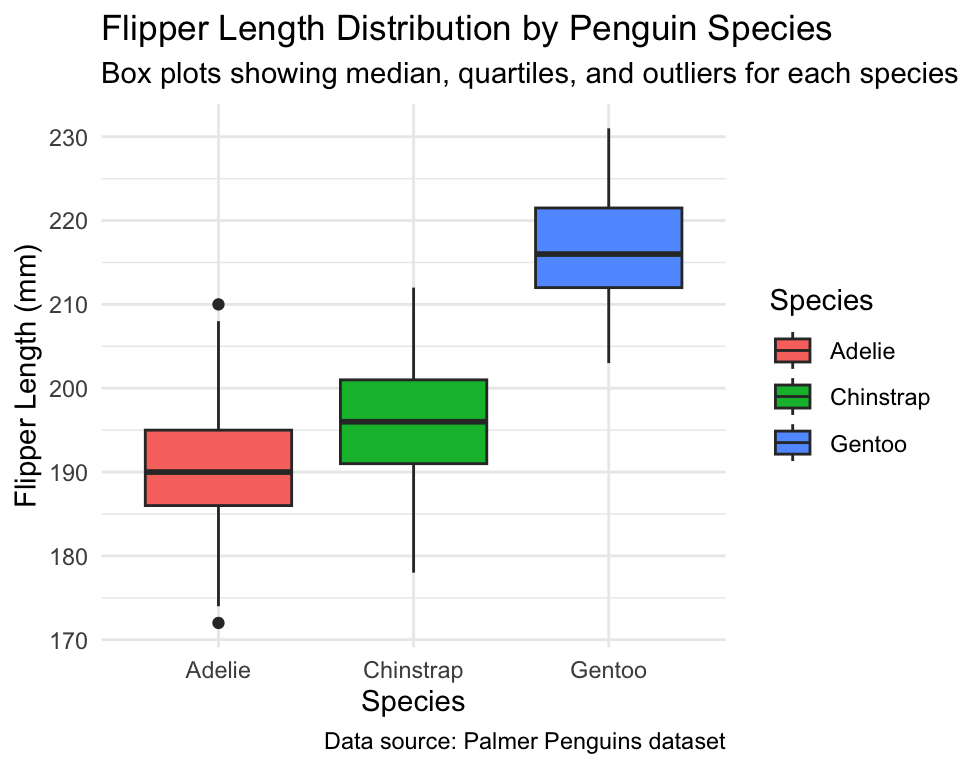

```r
plot3
```

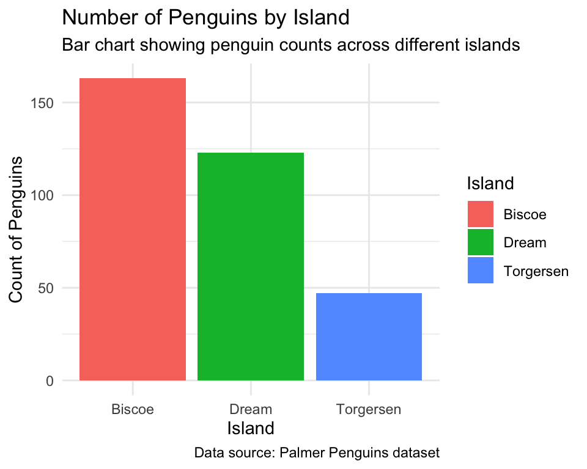

```r
plot4
```

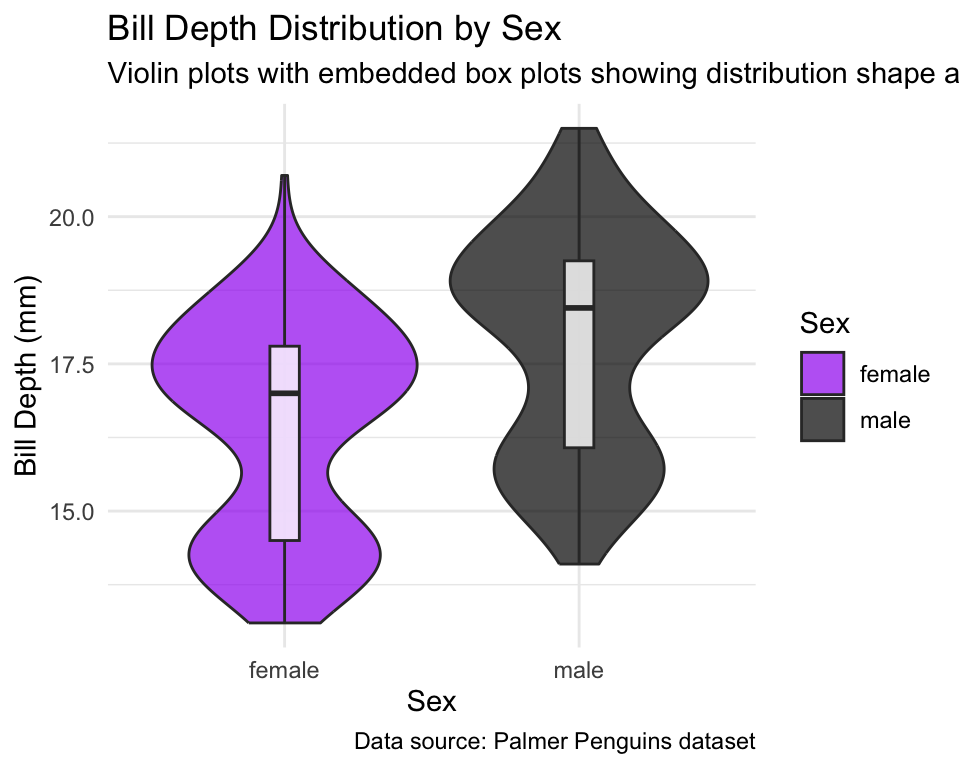

```r
plot5
```

```r
# Summary of plot choices
cat("PLOT CHOICES AND RATIONALE:",
    "1. HISTOGRAM - Bill Length: Shows frequency distribution of continuous data",
    "2. DENSITY PLOT - Body Mass: Shows smooth probability density of continuous data",
    "3. BOX PLOT - Flipper Length by Species: Compares distributions across categories",
    "4. BAR PLOT - Count by Island: Shows frequency of categorical data",
    "5. VIOLIN PLOT - Bill Depth by Sex: Shows full distribution shape + summary stats",
    sep = "\n")
```

```
## PLOT CHOICES AND RATIONALE:
## 1. HISTOGRAM - Bill Length: Shows frequency distribution of continuous data
## 2. DENSITY PLOT - Body Mass: Shows smooth probability density of continuous data
## 3. BOX PLOT - Flipper Length by Species: Compares distributions across categories
## 4. BAR PLOT - Count by Island: Shows frequency of categorical data
## 5. VIOLIN PLOT - Bill Depth by Sex: Shows full distribution shape + summary stats
```